# Import Required Libraries

```python
import pandas as pd
import numpy as np
import matplotlib.pyplot as plt
import seaborn as sns
from sklearn.model_selection import train_test_split
from sklearn.linear_model import LogisticRegression
from sklearn.metrics import confusion_matrix, classification_report
import plotly.express as px
import pycountry
from scipy import stats
from datasist.structdata import detect_outliers
from scipy.stats import mstats
import sweetviz as sv
from scipy.stats import ttest_ind
```

# Data Acquisition and Merging

```python
# Read the heart attack prediction dataset
heart_attack_df = pd.read_csv('heart_attack_prediction_dataset.csv')

# Read the diabetes prediction dataset
diabetes_df = pd.read_csv('diabetes_prediction_dataset.csv')
```

# Merge the Datasets

```python
# Merging datasets
# Perform inner join on 'Age' and 'Gender' in diabetes dataset and 'Age' and 'Sex' in heart attack dataset
merged_df = pd.merge(diabetes_df, heart_attack_df, left_on=['age', 'gender'], right_on=['Age', 'Sex'], how='inner')

# Drop the 'Sex' column as it is redundant after the join
merged_df.drop('Sex', axis=1, inplace=True)

df = merged_df.copy()

# Print the merged dataset
#print(merged_df)

# Export the merged dataset to a CSV file
#merged_df.to_csv('merged_dataset.csv', index=False)
```

# Data Exploration

```python
df.info()
df.describe()

# # Generate Sweetviz report for heart attack data
# heart_report = sv.analyze(heart_attack_df)
# heart_report.show_html('Heart_Report.html')

# # Generate Sweetviz report for diabetes data
# diabetes_report = sv.analyze(diabetes_df)
# diabetes_report.show_html('Diabetes_Report.html')

# # Generate Sweetviz report for merged data
# #merged_report = sv.analyze(df)
# #merged_report.show_html('Merged_Report.html')
```

```
<class 'pandas.core.frame.DataFrame'>
RangeIndex: 4544219 entries, 0 to 4544218
Data columns (total 34 columns):
 #   Column                           Dtype
---  ------                           -----
 0   gender                           object
 1   age                              float64
 2   hypertension                     int64
 3   heart_disease                    int64
 4   smoking_history                  object
 5   bmi                              float64
 6   HbA1c_level                      float64
 7   blood_glucose_level              int64
 8   diabetes                         int64
 9   Patient ID                       object
```

[output cut: 26 more lines]

|  | age | hypertension | heart_disease | bmi | HbA1c_level | blood_glucose_level | diabetes | Age | Cholesterol | Heart Rate | ... | Previous Heart Problems | Medication Use | Stress Level | Sedentary Hours Per Day | Income | BMI | Triglycerides | Physical Activity Days Per Week | Sleep Hours Per Day | Heart Attack Risk |
| --- | --- | --- | --- | --- | --- | --- | --- | --- | --- | --- | --- | --- | --- | --- | --- | --- | --- | --- | --- | --- | --- |
| count | 4.544219e+06 | 4.544219e+06 | 4.544219e+06 | 4.544219e+06 | 4.544219e+06 | 4.544219e+06 | 4.544219e+06 | 4.544219e+06 | 4.544219e+06 | 4.544219e+06 | ... | 4.544219e+06 | 4.544219e+06 | 4.544219e+06 | 4.544219e+06 | 4.544219e+06 | 4.544219e+06 | 4.544219e+06 | 4.544219e+06 | 4.544219e+06 | 4.544219e+06 |
| mean | 4.870492e+01 | 9.184372e-02 | 5.525570e-02 | 2.866244e+01 | 5.561064e+00 | 1.394279e+02 | 1.068428e-01 | 4.870492e+01 | 2.598257e+02 | 7.517452e+01 | ... | 4.988010e-01 | 4.968009e-01 | 5.483304e+00 | 5.989226e+00 | 1.588724e+05 | 2.889544e+01 | 4.159262e+02 | 3.481566e+00 | 7.042170e+00 | 3.540058e-01 |
| std | 1.802063e+01 | 2.888053e-01 | 2.284787e-01 | 5.814325e+00 | 1.090868e+00 | 4.214653e+01 | 3.089133e-01 | 1.802063e+01 | 8.112658e+01 | 2.067227e+01 | ... | 4.999986e-01 | 4.999898e-01 | 2.863620e+00 | 3.466693e+00 | 8.028971e+04 | 6.295612e+00 | 2.241141e+02 | 2.293353e+00 | 1.986633e+00 | 4.782110e-01 |
| min | 1.800000e+01 | 0.000000e+00 | 0.000000e+00 | 1.001000e+01 | 3.500000e+00 | 8.000000e+01 | 0.000000e+00 | 1.800000e+01 | 1.200000e+02 | 4.000000e+01 | ... | 0.000000e+00 | 0.000000e+00 | 1.000000e+00 | 1.263206e-03 | 2.006200e+04 | 1.800234e+01 | 3.000000e+01 | 0.000000e+00 | 4.000000e+00 | 0.000000e+00 |
| 25% | 3.400000e+01 | 0.000000e+00 | 0.000000e+00 | 2.592000e+01 | 4.800000e+00 | 1.000000e+02 | 0.000000e+00 | 3.400000e+01 | 1.910000e+02 | 5.700000e+01 | ... | 0.000000e+00 | 0.000000e+00 | 3.000000e+00 | 2.977844e+00 | 8.993200e+04 | 2.345229e+01 | 2.210000e+02 | 1.000000e+00 | 5.000000e+00 | 0.000000e+00 |
| 50% | 4.800000e+01 | 0.000000e+00 | 0.000000e+00 | 2.732000e+01 | 5.800000e+00 | 1.400000e+02 | 0.000000e+00 | 4.800000e+01 | 2.590000e+02 | 7.500000e+01 | ... | 0.000000e+00 | 0.000000e+00 | 5.000000e+00 | 5.931949e+00 | 1.588080e+05 | 2.876828e+01 | 4.170000e+02 | 3.000000e+00 | 7.000000e+00 | 0.000000e+00 |
| 75% | 6.300000e+01 | 0.000000e+00 | 0.000000e+00 | 3.059000e+01 | 6.200000e+00 | 1.590000e+02 | 0.000000e+00 | 6.300000e+01 | 3.300000e+02 | 9.300000e+01 | ... | 1.000000e+00 | 1.000000e+00 | 8.000000e+00 | 9.021488e+00 | 2.276160e+05 | 3.431461e+01 | 6.080000e+02 | 5.000000e+00 | 9.000000e+00 | 1.000000e+00 |
| max | 8.000000e+01 | 1.000000e+00 | 1.000000e+00 | 9.182000e+01 | 9.000000e+00 | 3.000000e+02 | 1.000000e+00 | 8.000000e+01 | 4.000000e+02 | 1.100000e+02 | ... | 1.000000e+00 | 1.000000e+00 | 1.000000e+01 | 1.199234e+01 | 2.999540e+05 | 3.999358e+01 | 8.000000e+02 | 7.000000e+00 | 1.000000e+01 | 1.000000e+00 |

8 rows × 26 columns

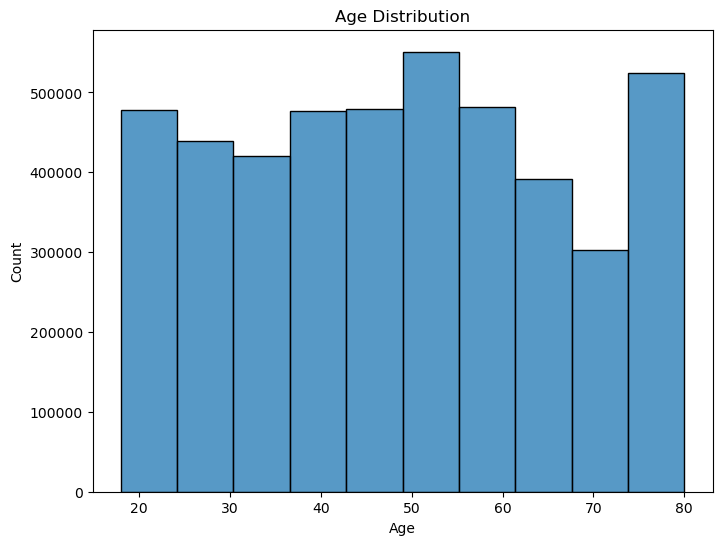

```
Mean BMI: 28.66
Median BMI: 27.32
Standard Deviation of BMI: 5.81
```

```python
# Histogram for age distribution
plt.figure(figsize=(8, 6))
sns.histplot(data=df, x="age", bins=10)
plt.title("Age Distribution")
plt.xlabel("Age")
plt.ylabel("Count")
plt.show()

# Summary statistics for BMI
bmi_mean = df["bmi"].mean()
bmi_median = df["bmi"].median()
bmi_std = df["bmi"].std()
print(f"Mean BMI: {bmi_mean:.2f}")
print(f"Median BMI: {bmi_median:.2f}")
print(f"Standard Deviation of BMI: {bmi_std:.2f}")
```

# Data Cleaning and Preprocessing

```python
# Checking for missing values
df.isnull().sum()
```

```
gender                             0
age                                0
hypertension                       0
heart_disease                      0
smoking_history                    0
bmi                                0
HbA1c_level                        0
blood_glucose_level                0
diabetes                           0
Patient ID                         0
Age                                0
Cholesterol                        0
Blood Pressure                     0
Heart Rate                         0
Diabetes                           0
Family History                     0
Smoking                            0
Obesity                            0
Alcohol Consumption                0
Exercise Hours Per Week            0
Diet                               0
Previous Heart Problems            0
Medication Use                     0
Stress Level                       0
Sedentary Hours Per Day            0
Income                             0
BMI                                0
Triglycerides                      0
Physical Activity Days Per Week    0
Sleep Hours Per Day                0
Country                            0
Continent                          0
Hemisphere                         0
Heart Attack Risk                  0
dtype: int64
```

## Remove Duplicates and Missing Values

```python
# Remove duplicate rows
df = df.drop_duplicates()

# Remove duplicate columns
df = df.loc[:,~df.columns.duplicated()]

# Check the column names
#print(df.columns)

# Remove the "diabetes" column and keep only the "Diabetes" column
df.drop("diabetes", axis=1, inplace=True)
df.rename(columns={"Diabetes": "diabetes"}, inplace=True)

# Remove the "diabetes" column and keep only the "Diabetes" column
df.drop("age", axis=1, inplace=True)
df.rename(columns={"Age": "age"}, inplace=True)

# Verify the updated column names
#print(df.columns)

# Remove missing values
#df = df.dropna()

# # Handling missing values
# # Imputation with median
# imputer = SimpleImputer(strategy='median')

# # Assuming 'age', 'bmi' columns have missing values
# df[['age', 'bmi']] = imputer.fit_transform(df[['age', 'bmi']])

# # For categorical columns, we can fill missing values with the most frequent category
# # Assuming 'smoking_history' is a categorical column with missing values
# df['smoking_history'].fillna(df['smoking_history'].mode()[0], inplace=True)

# # Check if there are still any missing values
# print(df.isnull().sum())
df.describe()
```

|  | hypertension | heart_disease | bmi | HbA1c_level | blood_glucose_level | age | Cholesterol | Heart Rate | diabetes | Family History | ... | Previous Heart Problems | Medication Use | Stress Level | Sedentary Hours Per Day | Income | BMI | Triglycerides | Physical Activity Days Per Week | Sleep Hours Per Day | Heart Attack Risk |
| --- | --- | --- | --- | --- | --- | --- | --- | --- | --- | --- | --- | --- | --- | --- | --- | --- | --- | --- | --- | --- | --- |
| count | 4.367149e+06 | 4.367149e+06 | 4.367149e+06 | 4.367149e+06 | 4.367149e+06 | 4.367149e+06 | 4.367149e+06 | 4.367149e+06 | 4.367149e+06 | 4.367149e+06 | ... | 4.367149e+06 | 4.367149e+06 | 4.367149e+06 | 4.367149e+06 | 4.367149e+06 | 4.367149e+06 | 4.367149e+06 | 4.367149e+06 | 4.367149e+06 | 4.367149e+06 |
| mean | 9.531962e-02 | 5.718857e-02 | 2.871699e+01 | 5.567777e+00 | 1.396535e+02 | 4.869252e+01 | 2.598156e+02 | 7.516356e+01 | 6.560949e-01 | 4.888226e-01 | ... | 4.987572e-01 | 4.967426e-01 | 5.481257e+00 | 5.987991e+00 | 1.588222e+05 | 2.889809e+01 | 4.160268e+02 | 3.481099e+00 | 7.039910e+00 | 3.542270e-01 |
| std | 2.936559e-01 | 2.322026e-01 | 5.924160e+00 | 1.094281e+00 | 4.239522e+01 | 1.791815e+01 | 8.109464e+01 | 2.066145e+01 | 4.750099e-01 | 4.998751e-01 | ... | 4.999985e-01 | 4.999894e-01 | 2.863453e+00 | 3.466547e+00 | 8.027622e+04 | 6.296829e+00 | 2.240667e+02 | 2.292840e+00 | 1.986910e+00 | 4.782785e-01 |
| min | 0.000000e+00 | 0.000000e+00 | 1.001000e+01 | 3.500000e+00 | 8.000000e+01 | 1.800000e+01 | 1.200000e+02 | 4.000000e+01 | 0.000000e+00 | 0.000000e+00 | ... | 0.000000e+00 | 0.000000e+00 | 1.000000e+00 | 1.263206e-03 | 2.006200e+04 | 1.800234e+01 | 3.000000e+01 | 0.000000e+00 | 4.000000e+00 | 0.000000e+00 |
| 25% | 0.000000e+00 | 0.000000e+00 | 2.573000e+01 | 4.800000e+00 | 1.000000e+02 | 3.400000e+01 | 1.910000e+02 | 5.700000e+01 | 0.000000e+00 | 0.000000e+00 | ... | 0.000000e+00 | 0.000000e+00 | 3.000000e+00 | 2.979946e+00 | 8.983900e+04 | 2.345229e+01 | 2.210000e+02 | 1.000000e+00 | 5.000000e+00 | 0.000000e+00 |
| 50% | 0.000000e+00 | 0.000000e+00 | 2.732000e+01 | 5.800000e+00 | 1.400000e+02 | 4.800000e+01 | 2.590000e+02 | 7.500000e+01 | 1.000000e+00 | 0.000000e+00 | ... | 0.000000e+00 | 0.000000e+00 | 5.000000e+00 | 5.916726e+00 | 1.587570e+05 | 2.876900e+01 | 4.170000e+02 | 3.000000e+00 | 7.000000e+00 | 0.000000e+00 |
| 75% | 0.000000e+00 | 0.000000e+00 | 3.083000e+01 | 6.200000e+00 | 1.590000e+02 | 6.300000e+01 | 3.300000e+02 | 9.300000e+01 | 1.000000e+00 | 1.000000e+00 | ... | 1.000000e+00 | 1.000000e+00 | 8.000000e+00 | 9.021387e+00 | 2.275410e+05 | 3.432174e+01 | 6.080000e+02 | 5.000000e+00 | 9.000000e+00 | 1.000000e+00 |
| max | 1.000000e+00 | 1.000000e+00 | 9.182000e+01 | 9.000000e+00 | 3.000000e+02 | 8.000000e+01 | 4.000000e+02 | 1.100000e+02 | 1.000000e+00 | 1.000000e+00 | ... | 1.000000e+00 | 1.000000e+00 | 1.000000e+01 | 1.199234e+01 | 2.999540e+05 | 3.999358e+01 | 8.000000e+02 | 7.000000e+00 | 1.000000e+01 | 1.000000e+00 |

8 rows × 24 columns

## Remove outliers from the dataset using Combined Method (Z-score and IQR)

IQR is based on percentiles and is not affected by the mean and standard deviation. It is useful in cases of skewed data. Z-score is based on standard deviation and is affected by the mean and standard deviation. It is useful in cases of normal distribution.

```python
# Calculate Z-scores
z_scores = np.abs(stats.zscore(df._get_numeric_data()))
df_no_outliers_z = df[(z_scores < 3).all(axis=1)]

# Calculate IQR
Q1 = df.quantile(0.25)
Q3 = df.quantile(0.75)
IQR = Q3 - Q1
df_no_outliers_iqr = df[~((df < (Q1 - 1.5 * IQR)) | (df > (Q3 + 1.5 * IQR))).any(axis=1)]

# Combine both methods
df_no_outliers = df_no_outliers_z.index.intersection(df_no_outliers_iqr.index)
df_final = df.loc[df_no_outliers]
```

Another Method using datasist library

```python
outlier_indices = detect_outliers(df, 0, df.columns)
#Remove outliers
#df_cleaned = df.drop(outlier_indices)
#Relplace outliers with median values
df_cleaned = df.copy()
for feature in df.columns:
    median = df[feature].median()
    df_cleaned.loc[outlier_indices, feature] = median
#Replace outliers with winsorized values
df_cleaned = df.copy()
for feature in df.columns:
    df_cleaned[feature] = mstats.winsorize(df[feature], limits=[0.05, 0.05])
```

# Statistical Analysis and Data Visualization

[figure not shown]

```python
# Correlation matrix for the dataset
# Correlation between variables
# Select numeric columns for correlation analysis
numeric_columns = df.select_dtypes(include=[float, int]).columns

# Calculate correlation matrix for numeric columns
correlation_matrix = df[numeric_columns].corr()

# Visualize correlation matrix
sns.heatmap(correlation_matrix, annot=True, cmap="coolwarm")
plt.title("Correlation Matrix")
plt.show()
```

### What are the most contributing risk factors for heart attack? Perform a statistical analysis to identify the factors that have the highest correlation or association with heart attacks. Consider variables such as age, sex, cholesterol levels, blood pressure, diabetes, family history, smoking, obesity, alcohol consumption, exercise hours per week, and previous heart problems.

```python
heart_attack_corr = correlation_matrix["Heart Attack Risk"].abs().sort_values(ascending=False)
print(heart_attack_corr)
```

```
Heart Attack Risk                  1.000000
Sleep Hours Per Day                0.029132
diabetes                           0.028447
Obesity                            0.024897
Cholesterol                        0.019384
Medication Use                     0.016075
Income                             0.015337
Smoking                            0.010251
age                                0.009638
Triglycerides                      0.007646
Heart Rate                         0.007367
Alcohol Consumption                0.006903
Stress Level                       0.006192
Previous Heart Problems            0.005369
Exercise Hours Per Week            0.004873
Physical Activity Days Per Week    0.004635
hypertension                       0.003740
heart_disease                      0.002459
Family History                     0.002072
bmi                                0.001629
BMI                                0.001550
blood_glucose_level                0.001514
HbA1c_level                        0.001063
Sedentary Hours Per Day            0.000222
Name: Heart Attack Risk, dtype: float64
```

### What are the most contributing risk factors for diabetes? Conduct a statistical analysis to determine the factors that have the strongest relationship with diabetes. Explore variables such as gender, age, hypertension, heart disease, smoking history, BMI (body mass index), HbA1c level, and blood glucose level.

```python
diabetes_corr = correlation_matrix["diabetes"].abs().sort_values(ascending=False)
print(diabetes_corr)
```

```
diabetes                           1.000000
Heart Attack Risk                  0.028447
Cholesterol                        0.023089
Previous Heart Problems            0.020121
Family History                     0.012943
Obesity                            0.012579
Sleep Hours Per Day                0.010396
Triglycerides                      0.009162
Stress Level                       0.008426
Heart Rate                         0.007921
Income                             0.005562
Sedentary Hours Per Day            0.004853
Physical Activity Days Per Week    0.003755
age                                0.003276
Smoking                            0.003160
BMI                                0.002322
heart_disease                      0.001838
bmi                                0.000920
Exercise Hours Per Week            0.000841
blood_glucose_level                0.000642
Medication Use                     0.000613
hypertension                       0.000304
HbA1c_level                        0.000169
Alcohol Consumption                0.000119
Name: diabetes, dtype: float64
```

### Are there any significant differences in risk factors between individuals with heart attacks and those with diabetes? Compare the distribution and characteristics of risk factors in these two groups using appropriate statistical tests. Identify any overlapping risk factors or unique factors associated with each condition.

```
T-Statistic: -42.827577964296296
P-Value: 0.0
```

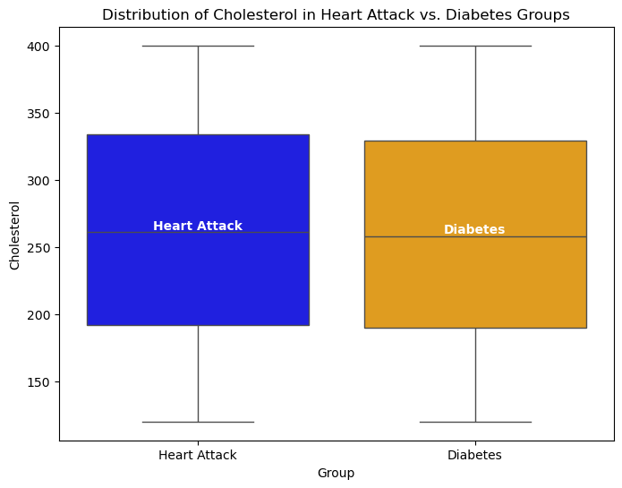

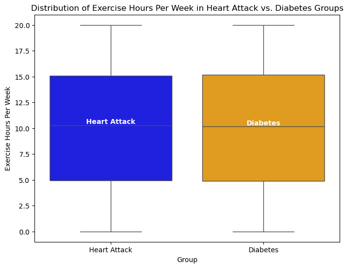

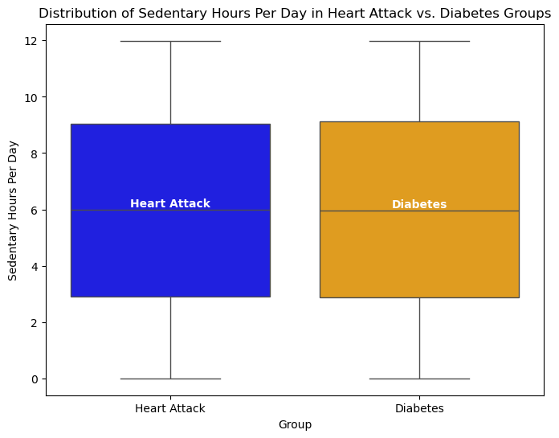

```python
heart_attack_group = df[df['Heart Attack Risk'] == 1]
diabetes_group = df[df['diabetes'] == 1]

risk_factor = 'Obesity'  # we can check fo other risk factor column name
t_statistic, p_value = ttest_ind(heart_attack_group[risk_factor], diabetes_group[risk_factor])
print(f"T-Statistic: {t_statistic}")
print(f"P-Value: {p_value}")

risk_factor = 'Cholesterol'  # we can check fo other risk factor column name
plt.figure(figsize=(8, 6))
sns.boxplot(x=['Heart Attack']*len(heart_attack_group[risk_factor]), y=heart_attack_group[risk_factor], color='blue')
sns.boxplot(x=['Diabetes']*len(diabetes_group[risk_factor]), y=diabetes_group[risk_factor], color='orange')
plt.xlabel('Group')
plt.ylabel(risk_factor)
plt.title(f"Distribution of {risk_factor} in Heart Attack vs. Diabetes Groups")

# Add labels to the boxplot
plt.text(0, np.median(heart_attack_group[risk_factor]), 'Heart Attack', ha='center', va='bottom', color='white', fontweight='bold')
plt.text(1, np.median(diabetes_group[risk_factor]), 'Diabetes', ha='center', va='bottom', color='white', fontweight='bold')

plt.show()

risk_factor = 'Exercise Hours Per Week'  # we can check fo other risk factor column name
plt.figure(figsize=(8, 6))
sns.boxplot(x=['Heart Attack']*len(heart_attack_group[risk_factor]), y=heart_attack_group[risk_factor], color='blue')
sns.boxplot(x=['Diabetes']*len(diabetes_group[risk_factor]), y=diabetes_group[risk_factor], color='orange')
plt.xlabel('Group')
plt.ylabel(risk_factor)
plt.title(f"Distribution of {risk_factor} in Heart Attack vs. Diabetes Groups")

# Add labels to the boxplot
plt.text(0, np.median(heart_attack_group[risk_factor]), 'Heart Attack', ha='center', va='bottom', color='white', fontweight='bold')
plt.text(1, np.median(diabetes_group[risk_factor]), 'Diabetes', ha='center', va='bottom', color='white', fontweight='bold')

plt.show()

risk_factor = 'Sedentary Hours Per Day'  # we can check fo other risk factor column name
plt.figure(figsize=(8, 6))
sns.boxplot(x=['Heart Attack']*len(heart_attack_group[risk_factor]), y=heart_attack_group[risk_factor], color='blue')
sns.boxplot(x=['Diabetes']*len(diabetes_group[risk_factor]), y=diabetes_group[risk_factor], color='orange')
plt.xlabel('Group')
plt.ylabel(risk_factor)
plt.title(f"Distribution of {risk_factor} in Heart Attack vs. Diabetes Groups")

# Add labels to the boxplot
plt.text(0, np.median(heart_attack_group[risk_factor]), 'Heart Attack', ha='center', va='bottom', color='white', fontweight='bold')
plt.text(1, np.median(diabetes_group[risk_factor]), 'Diabetes', ha='center', va='bottom', color='white', fontweight='bold')

plt.show()
```

T-Statistic: -42.827577964296296 The t-statistic measures the difference in means between the two groups relative to the variability within each group. In this case, the negative value indicates that the mean obesity level in the heart attack group is lower than in the diabetes group.

P-Value: 0.0 The p-value represents the probability of observing the t-statistic given that the null hypothesis is true (i.e., there is no difference between the groups). A p-value of 0.0 suggests extremely strong evidence against the null hypothesis. Therefore, we can conclude that there is a significant difference in obesity levels between individuals with heart attacks and those with diabetes.

```python
# Add a 'Group' column to each group
heart_attack_group['Group'] = 'Heart Attack'
diabetes_group['Group'] = 'Diabetes'

# Concatenate the two groups into a single DataFrame
combined_groups = pd.concat([heart_attack_group, diabetes_group])

# Select the columns you want to include in the pairplot
# numeric_columns_to_plot = ['age', 'Cholesterol', 'Obesity', 'Exercise Hours Per Week', 'Sedentary Hours Per Day']
numeric_columns_to_plot = ['age', 'Cholesterol', 'Obesity']
#
# sns.pairplot(combined_groups, vars=columns_to_plot, hue='Group', diag_kind='kde')
# plt.title("Pairplot of Risk Factors for Heart Attack vs. Diabetes Groups")
# plt.show()
# Create a pairplot for the numeric variables
# sns.pairplot(combined_groups, vars=numeric_columns_to_plot, hue='Group', diag_kind='kde')
# plt.title("Pairplot of Risk Factors for Heart Attack vs. Diabetes Groups")
# plt.show()
```

### Is there a relationship between obesity and the occurrence of heart attacks or diabetes? Analyze the correlation between obesity and the presence of heart attacks or diabetes. Consider other variables that may interact with obesity, such as age, sex, and lifestyle factors.

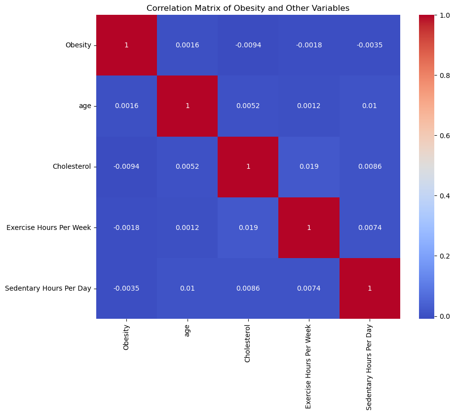

```python
# Select relevant columns for analysis
columns_of_interest = ['Obesity', 'age', 'Cholesterol', 'Exercise Hours Per Week', 'Sedentary Hours Per Day']
# Compute the correlation matrix
correlation_matrix = combined_groups[columns_of_interest].corr()

# Create a heatmap to visualize the correlation matrix
plt.figure(figsize=(10, 8))
sns.heatmap(correlation_matrix, annot=True, cmap='coolwarm', square=True)
plt.title("Correlation Matrix of Obesity and Other Variables")
plt.show()
```

### Are there any interactions or synergistic effects between risk factors for heart attacks and diabetes? Investigate potential interactions between variables to determine if certain combinations of risk factors pose a higher risk for developing both conditions concurrently.

```python
# Calculate the conditional probabilities of risk factors given both heart attacks and diabetes
conditional_probabilities = pd.crosstab(index=combined_groups['Obesity'],
                                       columns=[combined_groups['Cholesterol'],
                                                combined_groups['Blood Pressure']],
                                       normalize='index')

print("Conditional Probabilities of Risk Factors Given Both Heart Attacks and Diabetes:")
print(conditional_probabilities)
```

```
Conditional Probabilities of Risk Factors Given Both Heart Attacks and Diabetes:
Cholesterol          120                                                   \
Blood Pressure    101/90    103/83    105/87  107/106    107/65   109/107
Obesity
0               0.000000  0.000765  0.000137  0.00000  0.000000  0.000269
1               0.000187  0.000000  0.000000  0.00023  0.000548  0.000000

Cholesterol                                           ...      400            \
Blood Pressure    123/89  124/107    129/66   130/83  ...  142/100   149/106
Obesity                                               ...
0               0.000252  0.00000  0.000000  0.00069  ...  0.00069  0.000000
1               0.000000  0.00024  0.000373  0.00000  ...  0.00000  0.000748

Cholesterol                                                                 \
Blood Pressure    152/77    158/63    159/67    159/91    169/78    175/84
Obesity
0               0.000000  0.000169  0.000000  0.000000  0.000000  0.000722
1               0.000693  0.000000  0.000222  0.000237  0.000316  0.000000

Cholesterol
Blood Pressure     97/78     99/92
Obesity
0               0.000000  0.000000
1               0.000502  0.000186

[2 rows x 5818 columns]
```

# Prevalence Calculation and Assessment

### What is the overall prevalence of heart attacks and diabetes in the dataset? Calculate the prevalence rates for each condition and assess their distribution across different demographic and risk factor categories.

```python
# Calculate prevalence rates
# Assuming 'heart_attack_risk' is a binary column with 1 indicating heart attack and 0 indicating no heart attack
heart_attack_prevalence = df['Heart Attack Risk'].mean()
print(f"Heart Attack Prevalence: {heart_attack_prevalence * 100}%")

# Assuming 'diabetes' is a binary column with 1 indicating diabetes and 0 indicating no diabetes
diabetes_prevalence = df['diabetes'].mean()
print(f"Diabetes Prevalence: {diabetes_prevalence * 100}%")
```

```
Heart Attack Prevalence: 35.42269796611016%
Diabetes Prevalence: 65.60948573085095%
```

```python
# Calculate the overall prevalence of heart attacks and diabetes
overall_heart_attack_prevalence = df['Heart Attack Risk'].mean()
overall_diabetes_prevalence = df['diabetes'].mean()

# Print the overall prevalence rates
print(f"Overall Prevalence of Heart Attacks: {overall_heart_attack_prevalence}")
print(f"Overall Prevalence of Diabetes: {overall_diabetes_prevalence}")

# Assess the distribution of heart attacks and diabetes across demographic and risk factor categories
demographic_columns = ['age', 'gender']
risk_factor_columns = ['Obesity', 'Cholesterol', 'Blood Pressure']

for column in demographic_columns:
    group_counts = df.groupby(column)[['Heart Attack Risk', 'diabetes']].mean()
    print(f"\nPrevalence of Heart Attacks and Diabetes by {column}:")
    print(group_counts)

for column in risk_factor_columns:
    group_counts = df.groupby(column)[['Heart Attack Risk', 'diabetes']].mean()
    print(f"\nPrevalence of Heart Attacks and Diabetes by {column}:")
    print(group_counts)
```

```
Overall Prevalence of Heart Attacks: 0.35422697966110156
Overall Prevalence of Diabetes: 0.6560948573085095

Prevalence of Heart Attacks and Diabetes by age:
     Heart Attack Risk  diabetes
age
18            0.322759  0.631186
19            0.314939  0.622073
20            0.301006  0.658487
21            0.355836  0.663420
22            0.313671  0.653497
..                 ...       ...
76            0.347569  0.578901
77            0.384394  0.607656
78            0.339903  0.720302
79            0.330088  0.657142
80            0.323114  0.672506

[63 rows x 2 columns]

Prevalence of Heart Attacks and Diabetes by gender:
        Heart Attack Risk  diabetes
gender
Female           0.351653  0.654069
Male             0.355930  0.657435

Prevalence of Heart Attacks and Diabetes by Obesity:
         Heart Attack Risk  diabetes
Obesity
0                 0.366254  0.650060
1                 0.342438  0.662011

Prevalence of Heart Attacks and Diabetes by Cholesterol:
             Heart Attack Risk  diabetes
Cholesterol
120                   0.362322  0.539362
121                   0.229822  0.580559
122                   0.475951  0.744503
123                   0.327189  0.690988
124                   0.105557  0.586064
```

[output cut: 10 more lines]

```
                Heart Attack Risk  diabetes
Blood Pressure
100/100                  0.000000  1.000000
100/102                  0.000000  1.000000
100/103                  0.467304  0.754527
100/104                  0.000000  0.512397
100/105                  0.291279  0.359018
...                           ...       ...
99/92                    0.350166  0.624585
99/93                    0.000000  1.000000
99/94                    0.000000  1.000000
99/96                    0.683443  0.683443
99/98                    0.000000  0.000000

[3697 rows x 2 columns]
```

```python
# Correlation matrix for the dataset
# Correlation between variables
# Select numeric columns for correlation analysis
numeric_columns = df.select_dtypes(include=[float, int]).columns

# Calculate correlation matrix for numeric columns
correlation_matrix = df[numeric_columns].corr()


# Important risk factors for heart attack
# Replace 'heart_attack_risk' with the actual column name for heart attack risk in your dataset
important_factors_heart = correlation_matrix['Heart Attack Risk'].sort_values(ascending=False)

# Important risk factors for diabetes
# Replace 'diabetes' with the actual column name for diabetes in your dataset
important_factors_diabetes = correlation_matrix['diabetes'].sort_values(ascending=False)

#print(important_factors_heart)
#print(important_factors_diabetes)

# Candidate Features for ML Modeling
candidate_features = ["age", "bmi", "HbA1c_level","blood_glucose_level", "hypertension", "heart_disease", "smoking_history", "Cholesterol"]

# Select the relevant columns as features
X = df[candidate_features]

# Select the target variable (heart attack)
y_heart_attack = df["Heart Attack Risk"]

# Select the target variable (diabetes)
y_diabetes = df["diabetes"]

# Print the first few rows of the features and target variables
print("Features:")
print(X.head())
print("\nHeart Attack Risk:")
print(y_heart_attack.head())
print("\nDiabetes:")
print(y_diabetes.head())
```

```
Features:
   age    bmi  HbA1c_level  blood_glucose_level  hypertension  heart_disease  \
0   80  25.19          6.6                  140             0              1
1   80  25.19          6.6                  140             0              1
2   80  25.19          6.6                  140             0              1
3   80  25.19          6.6                  140             0              1
4   80  25.19          6.6                  140             0              1

  smoking_history  Cholesterol
0           never          263
1           never          270
2           never          328
3           never          376
4           never          384

Heart Attack Risk:
0    0
1    1
2    0
3    1
4    0
Name: Heart Attack Risk, dtype: int64

Diabetes:
0    1
1    1
2    0
3    1
4    1
Name: diabetes, dtype: int64
```

```python
# Helper Function to get ISO Alpha-3 country code from country name
def get_country_code(country_name):
    try:
        country = pycountry.countries.get(name=country_name)
        return country.alpha_3
    except:
        return None

# Sample a small portion of the DataFrame to reduce computation time and memory usage
sample_size = 100  # Specify the desired sample size
df_sample = df.sample(n=sample_size, random_state=1)

# Add ISO Alpha-3 country codes to the sampled DataFrame
df_sample["iso_a3"] = df_sample["Country"].apply(get_country_code)

# Remove rows with missing country codes
df_sample = df_sample.dropna(subset=["iso_a3"])

# Visualize Diabetes by Country
fig = px.choropleth(df_sample,
                    locations="iso_a3",
                    color="diabetes",
                    color_continuous_scale="YlOrRd",
                    title="Diabetes Prevalence by Country",
                    labels={"Diabetes": "Diabetes Prevalence"},)
                   # hover_name="Country")
fig.show()

# Visualize Heart Attack by Country
fig = px.choropleth(df_sample,
                    locations="iso_a3",
                    color="Heart Attack Risk",
                    color_continuous_scale="YlOrRd",
                    title="Heart Attack Risk by Country",
                    labels={"Heart Attack Risk": "Heart Attack Risk"},)
                    #hover_name="Country")
fig.show()



# Visualize Diabetes by Country
# world = gpd.read_file(gpd.datasets.get_path("naturalearth_lowres"))
# merged_df = world.merge(df, left_on="name", right_on="Country", how="left")

# plt.figure(figsize=(12, 8))
# merged_df.plot(column="diabetes", cmap="YlOrRd", linewidth=0.8, edgecolor="0.8", legend=True)
# plt.title("Diabetes Prevalence by Country")
# plt.show()

# # Visualize Heart Attack by Country
# plt.figure(figsize=(12, 8))
# merged_df.plot(column="Heart Attack Risk", cmap="YlOrRd", linewidth=0.8, edgecolor="0.8", legend=True)
# plt.title("Heart Attack Risk by Country")
# plt.show()

# # Visualize Diabetes by Country
# fig = px.choropleth(df,
#                     locations="iso_a3",
#                     color="Diabetes",
#                     color_continuous_scale="YlOrRd",
#                     title="Diabetes Prevalence by Country",
#                     labels={"Diabetes": "Diabetes Prevalence"},
#                     hover_name="Country")
# fig.update_geos(showcountries=True, countrycolor="gray")
# fig.show()

# # Visualize Heart Attack by Country
# fig = px.choropleth(df,
#                     locations="iso_a3",
#                     color="Heart Attack Risk",
#                     color_continuous_scale="YlOrRd",
#                     title="Heart Attack Risk by Country",
#                     labels={"Heart Attack Risk": "Heart Attack Risk"},
#                     hover_name="Country")
# fig.update_geos(showcountries=True, countrycolor="gray")
# fig.show()
# # Add ISO Alpha-3 country codes to the DataFrame
# df["iso_a3"] = df["Country"].apply(get_country_code)

# # Remove rows with missing country codes
# df = df.dropna(subset=["iso_a3"])

# # Visualize Diabetes by Country
# fig = px.choropleth(df,
#                     locations="iso_a3",
#                     color="Diabetes",
#                     color_continuous_scale="YlOrRd",
#                     title="Diabetes Prevalence by Country",
#                     labels={"Diabetes": "Diabetes Prevalence"},)
#                     #hover_name="Country")
# fig.show()
# # Visualize Heart Attack by Country
# fig = px.choropleth(df,
#                     locations="iso_a3",
#                     color="Heart Attack Risk",
#                     color_continuous_scale="YlOrRd",
#                     title="Heart Attack Risk by Country",
#                     labels={"Heart Attack Risk": "Heart Attack Risk"},)
#                     #hover_name="Country")
# fig.show()
```

[output not shown]